# Lab 6

Erin de Leon Sanchez

11/1/2021

## Example of a rank-based test

We’ll make our own samples, using a pseudorandom generator

```r
set.seed(1414)
gp_1 <- sample.int(20, size = 15, replace = TRUE)

set.seed(1424)
gp_2 <- sample.int(30, size = 15, replace = TRUE)
```

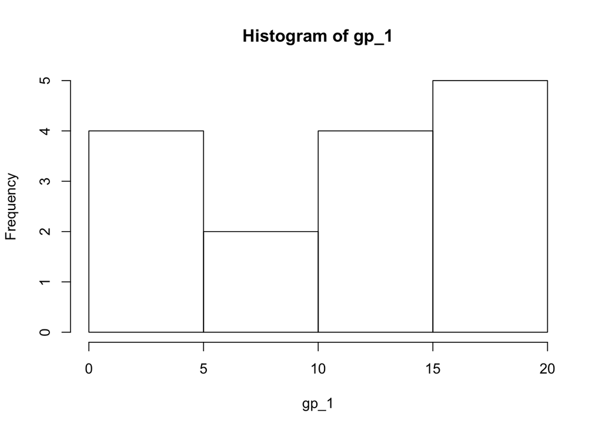

```r
hist(gp_1)
```

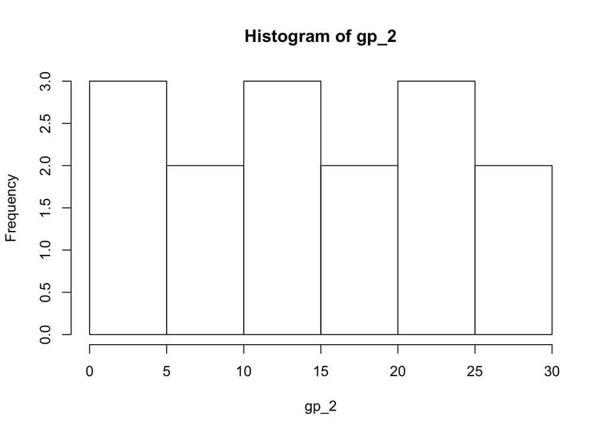

```r
hist(gp_2)
```

Try a t-test:

```r
t.test(gp_1, gp_2)
```

```
##
##  Welch Two Sample t-test
##
## data:  gp_1 and gp_2
## t = -1.3241, df = 23.545, p-value = 0.1982
## alternative hypothesis: true difference in means is not equal to 0
## 95 percent confidence interval:
##  -9.558315  2.091648
## sample estimates:
## mean of x mean of y
##  11.40000  15.13333
```

What is the meaning of the p-value? If these samples were drawn from populations with the same mean, the probability of taking two random samples with means *at least as different* as the sample means we found by random chance (taking into account spread, n) is 19.8%.

Retain (fail to reject) the null hypothesis. >> There is no significant difference in means between group 1 and group 2.

Warning: people get wirdly upset if you say “accept” the null.

Now let’s compare this outcome to a rank-based test.

## Mann Whitney U unpaired rank-based test

```r
mwu <- wilcox.test(gp_1, gp_2)
```

```
## Warning in wilcox.test.default(gp_1, gp_2): cannot compute exact p-value with
## ties
```

```r
mwu
```

```
##
##  Wilcoxon rank sum test with continuity correction
##
## data:  gp_1 and gp_2
## W = 86, p-value = 0.28
## alternative hypothesis: true location shift is not equal to 0
```

Meaning of p-value of 0.28: If these samples were drawn from populations with the same ranks (medians), the probability of finding two samples with ranks *at least as different* as those in our samples is 0.28.

There is no significant difference in ranks (often you’ll see medians) between group 1 and group 2 (statistical summary).

Median scores for group 1 (M = 14) and group 2 (M = 12) did not differ significantly (Mann Whitney U test: U(df) = 86, p = 0.28)

To look at documentation: type in `?wilcox.test` then you can recall values with `mwu$p.value`, etc.

## Linear regression

Simple linear regression (single dependent variable, a single independent variable)

Find a linear regression model using ordinary least squares describing the relationship between flipper length and body mass for these penguins.

3 pieces:

- What type of model?
- What is the relationship to model (DV - IV(s))?
- Where is the data that’s sued to create this model?

```r
penguin_lm <- lm(body_mass_g ~ flipper_length_mm, data = penguins)
```

y = mx + b y is body mass x is flipper length body mass = 49.7(flipper length) - 5780.83 what is the coefficient for flipper length? The slope! On average, I expect for every one mm increase in flipper length, I expect a 49.7 gram increase in body mass! units = g/mm

### broom package returns model outputs as tidy data frames

```r
penguin_lm_tidy <- broom::tidy(penguin_lm)

broom::glance(penguin_lm) #gives model-wide uncertainties and whatnot in a nice data frame - more on Wednesday
```

```
## # A tibble: 1 × 12
##   r.squared adj.r.squared sigma statistic   p.value    df logLik   AIC   BIC
##       <dbl>         <dbl> <dbl>     <dbl>     <dbl> <dbl>  <dbl> <dbl> <dbl>
## 1     0.759         0.758  394.     1071. 4.37e-107     1 -2528. 5063. 5074.
## # … with 3 more variables: deviance <dbl>, df.residual <int>, nobs <int>
```

How can I actually include my model equation in a report?

```r
extract_eq(model = penguin_lm, use_coefs = TRUE)
```

$$\operatorname{\widehat{body\_mass\_g}} = -5780.83 + 49.69(\operatorname{flipper\_length\_mm})$$

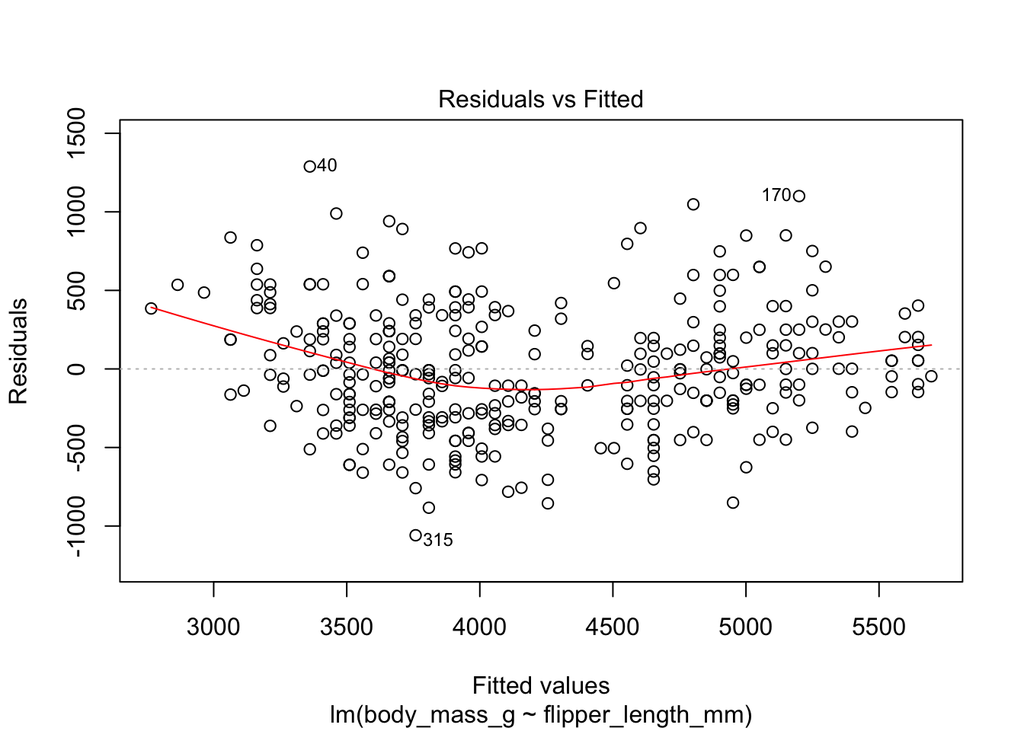

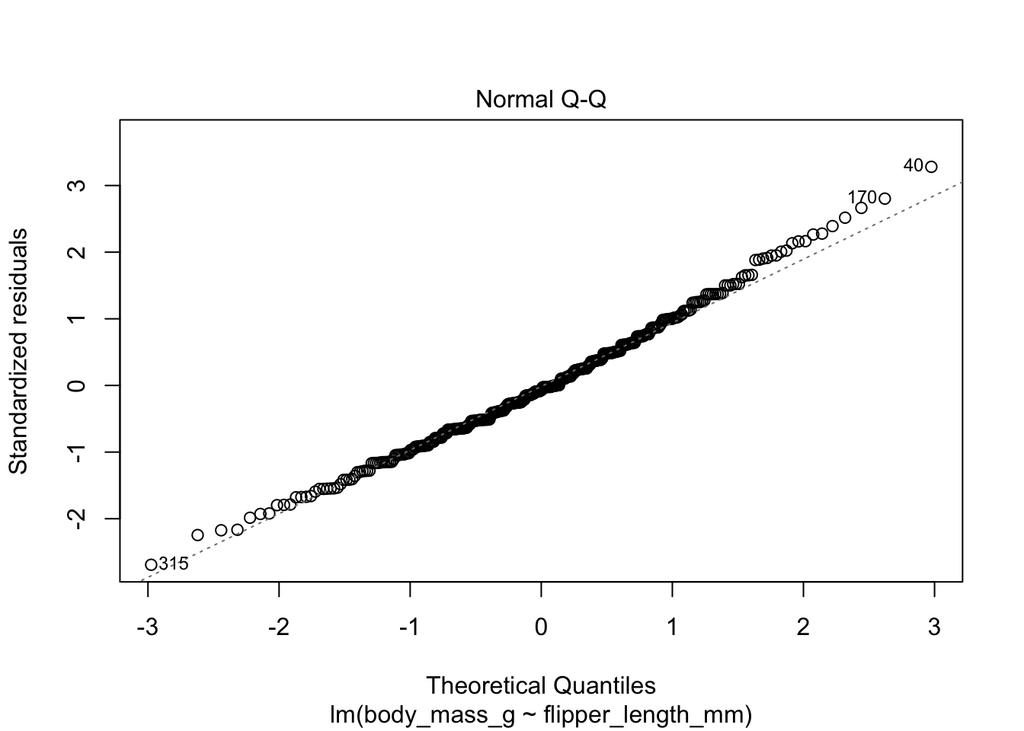

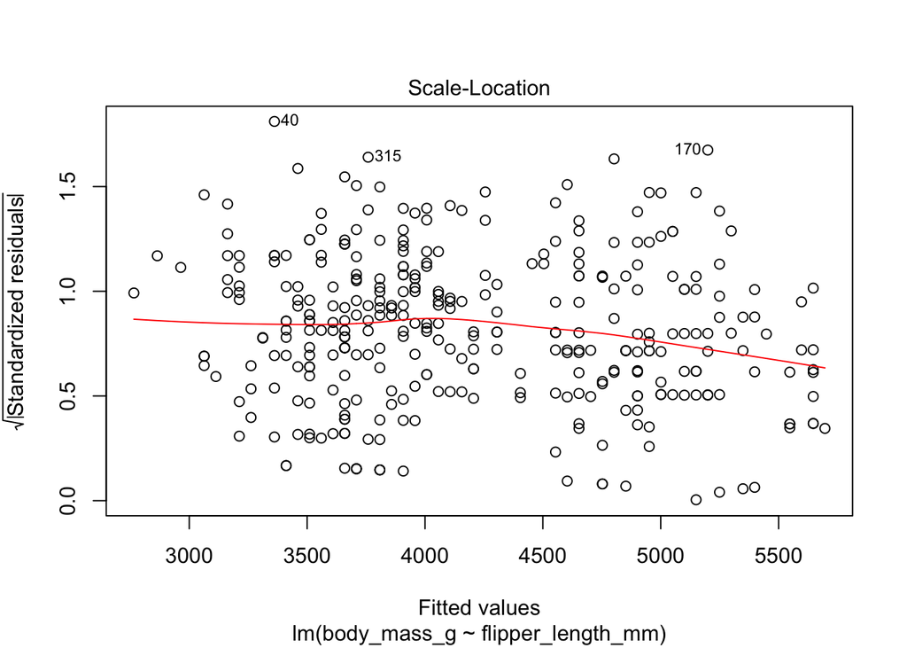

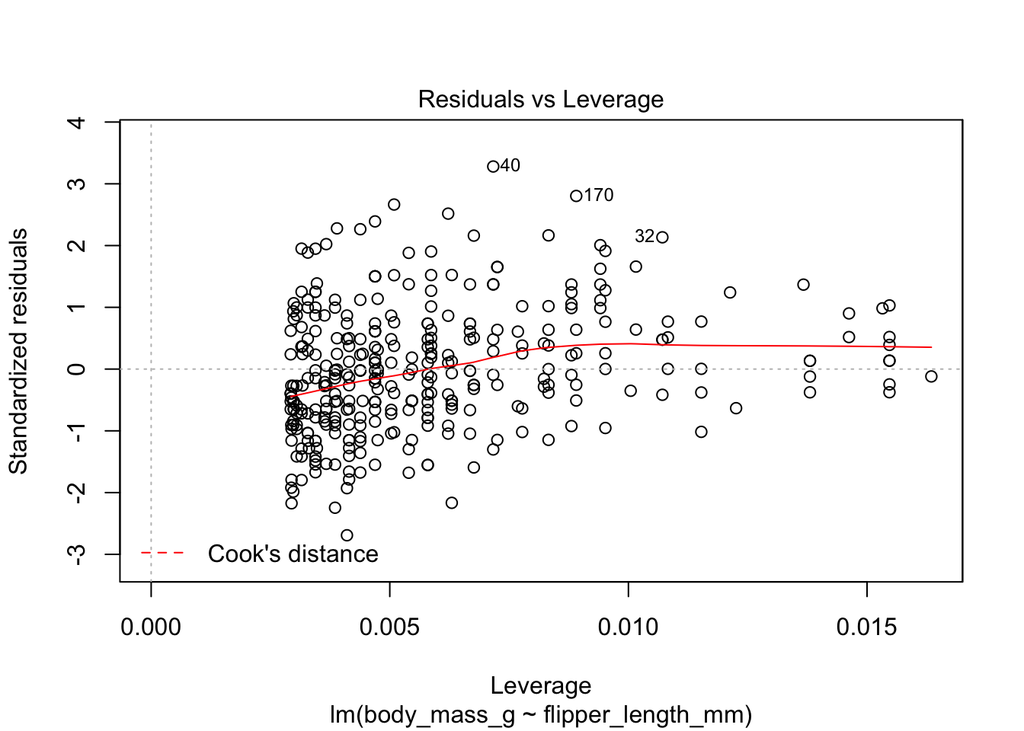

```r
plot(penguin_lm)
```